# NR6A1 in snRNA Datasets

# Three sources of data:

Rui Chen’s Human Retina Cell Atlas *and* fetal Human Retina Cell Atlas

And GTEx’s prototype single cell atlas.

# Why not David’s plae resource?

Well, I’d love to another citation, but NR6A1 isn’t well detected in single cell RNAseq (not shown why). All of the resources used here are single **nucleus** RNA-seq - which capture the RNA from the nucleus of the cell.

For some reason NR6A1 transcripts are fairly well represented in the nucleus, but are not captured well (perhaps counts too low?) in the full cell.

# tldr

Evidence of higher NR6A1 (in both fetal and adult retina datasets) in the horizontal cells (HC).

# Dataset

snRNA h5ad retrieved from [here](https://cellxgene.cziscience.com/collections/4c6eaf5c-6d57-4c76-b1e9-60df8c655f1e) and [here](https://cellxgene.cziscience.com/collections/4832df54-d357-4d0f-b601-e924823b38b7) on 2024-05-15.

Downloaded [adult](https://datasets.cellxgene.cziscience.com/89f6a640-0537-4fd1-bdf9-540db9dd0b7d.h5ad) and [fetal](https://datasets.cellxgene.cziscience.com/88444d73-7f55-4a62-bcfe-e929878c6c78.h5ad)

Download the [GTEx v8 data](https://storage.googleapis.com/adult-gtex/single-cell/v9/snrna-seq-data/GTEx_8_tissues_snRNAseq_atlas_071421.public_obs.h5ad) on 2024-05-16.

# Methods

The single nucleus data was aggregated (with the ADPBulk python package) to the cell type and sample level by *summing* the counts. This is also known as a “pseudobulk” process as it turns single cells into a data type with the rough properties of a bulk RNA-seq dataset.

“pseudobulk” samples with lower overall counts (derived by hand inspecting) the overall distributions of overall expression were removed.

The data was CPM scaled and log1p transformed for plotting.

```r
mamba activate scvi1.0.4
python src/adata_to_pseudobulk.py ~/data/chen_rca/chen_fetal_hrca_snRNA_88444d73-7f55-4a62-bcfe-e929878c6c78.h5ad donor_id,development_stage,majorclass data/chen_fetal_hrca.pb_raw.csv.gz

python src/adata_to_pseudobulk.py ~/data/chen_rca/chen_adult_hrca_snRNA_89f6a640-0537-4fd1-bdf9-540db9dd0b7d.h5ad donor_id,majorclass data/chen_adult_hrca.pb_raw.csv.gz

python src/adata_to_pseudobulk.py /Users/mcgaugheyd/data/gtex/GTEx_8_tissues_snRNAseq_atlas_071421.public_obs.h5ad  Sample\ ID,Tissue,Broad\ cell\ type data/gtex_v8_pb.csv.gz
```

```r
library(tidyverse)
pb <- data.table::fread("../data/chen_adult_hrca.pb_raw.csv.gz")
pb_mat <- pb[,2:ncol(pb)] %>% as.matrix()
row.names(pb_mat) <- pb %>% pull(1)
pb_mat <- pb_mat[pb_mat %>% rowSums() %>% log1p() > 12,]


pb_transform <- t(metamoRph::normalize_data(t(pb_mat), log1p = TRUE))
```

```
Sample CPM scaling
log1p scaling
```

# Pull gene names

```r
conv_table <- AnnotationDbi::select(org.Hs.eg.db::org.Hs.eg.db,
                                    keys=colnames(pb),
                                    columns=c("ENSEMBL","SYMBOL", "MAP","GENENAME", "ENTREZID"), keytype="ENSEMBL")
conv_table %>% head()
```

|  | ENSEMBL | SYMBOL | MAP | GENENAME | ENTREZID |
| --- | --- | --- | --- | --- | --- |
| 1 | V1 | NA | NA | NA | NA |
| 2 | ENSG00000000003 | TSPAN6 | Xq22.1 | tetraspanin 6 | 7105 |
| 3 | ENSG00000000005 | TNMD | Xq22.1 | tenomodulin | 64102 |
| 4 | ENSG00000000419 | DPM1 | 20q13.13 | dolichyl-phosphate mannosyltransferase subunit 1, catalytic | 8813 |
| 5 | ENSG00000000457 | SCYL3 | 1q24.2 | SCY1 like pseudokinase 3 | 57147 |
| 6 | ENSG00000000460 | FIRRM | 1q24.2 | FIGNL1 interacting regulator of recombination and mitosis | 55732 |

```r
pb_long <- pb_transform %>% as_tibble(rownames = 'info') %>% separate(info, c("donor","class"), sep = '-majorclass\\.') %>%
  mutate(donor = gsub("donor_id\\.","",donor)) %>%
  pivot_longer(cols = starts_with("ENSG"))
```

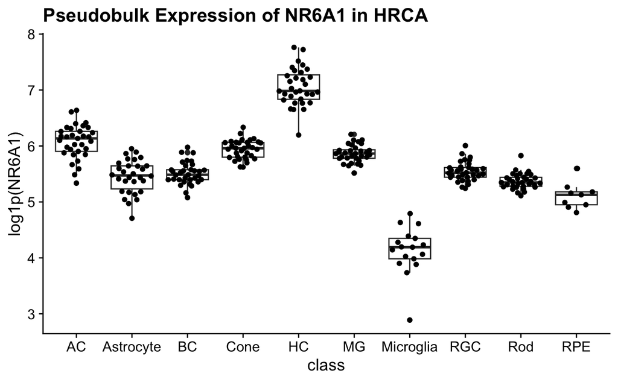

```r
pb_long %>%
  left_join(conv_table %>% group_by(ENSEMBL) %>% summarise(SYMBOL = paste(SYMBOL, collapse= ', ')),
            by = c("name" = "ENSEMBL")) %>%
  filter(SYMBOL == 'NR6A1') %>%
  ggplot(aes(x=class,y=(value))) +
  geom_boxplot() +
  ggbeeswarm::geom_quasirandom() +
  ylab("log1p(NR6A1)") +
  cowplot::theme_cowplot() +
  ggtitle("Pseudobulk Expression of NR6A1 in HRCA")
```

# fetal

```r
pb_fetal <- data.table::fread("../data/chen_fetal_hrca.pb_raw.csv.gz")
pb_mat_fetal <- pb_fetal[,2:ncol(pb_fetal)] %>% as.matrix()
row.names(pb_mat_fetal) <- pb_fetal %>% pull(1)
# pb_mat %>% rowSums() %>% log1p() %>%  density() %>% plot()
pb_mat_fetal <- pb_mat_fetal[pb_mat_fetal %>% rowSums() %>% log1p() > 12,]


pb_transform_fetal <- t(metamoRph::normalize_data(t(pb_mat_fetal), log1p = TRUE))
```

```
Sample CPM scaling
log1p scaling
```

```r
pb_long_fetal <- pb_transform_fetal %>% as_tibble(rownames = 'info') %>% separate(info, c("donor","class"), sep = '-majorclass\\.') %>%
  mutate(age = str_extract(donor, '\\d+th|\\d+st') %>% gsub('th|st','',.) %>% as.integer()) %>%
  pivot_longer(cols = starts_with("ENSG"))
```

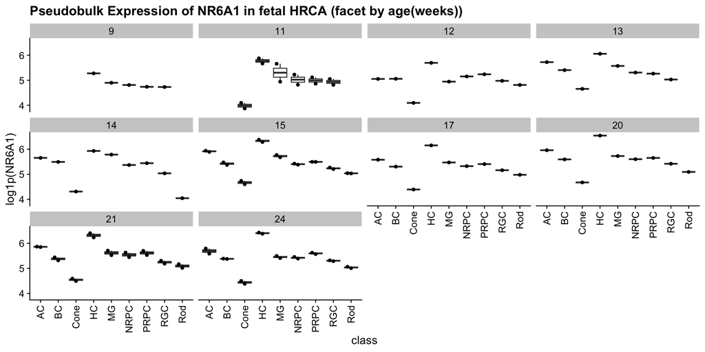

```r
pb_long_fetal %>%
  left_join(conv_table %>% group_by(ENSEMBL) %>% summarise(SYMBOL = paste(SYMBOL, collapse= ', ')),
            by = c("name" = "ENSEMBL")) %>%
  filter(SYMBOL == 'NR6A1') %>%
  ggplot(aes(x=class,y=(value))) +
  facet_wrap(~age) +
  geom_boxplot() +
  ggbeeswarm::geom_quasirandom() +
  ylab("log1p(NR6A1)") +
  cowplot::theme_cowplot() +
  ggtitle("Pseudobulk Expression of NR6A1 in fetal HRCA (facet by age(weeks))") +
  scale_x_discrete(guide = guide_axis(angle = 90))
```

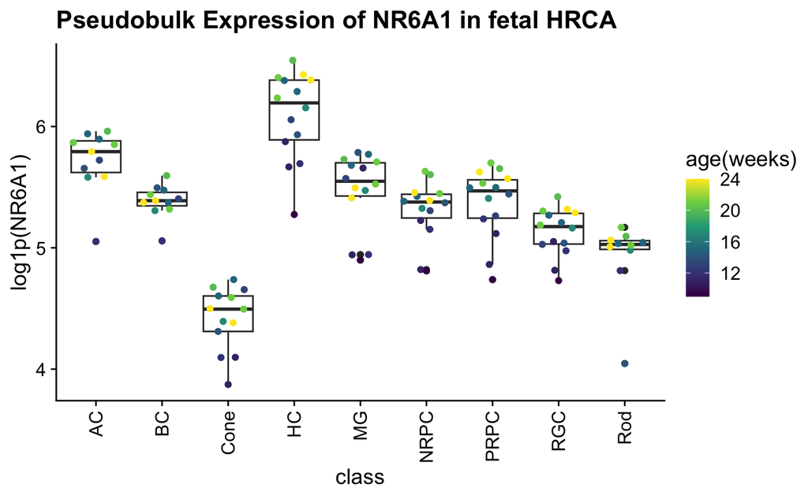

```r
pb_long_fetal %>%
  left_join(conv_table %>% group_by(ENSEMBL) %>% summarise(SYMBOL = paste(SYMBOL, collapse= ', ')),
            by = c("name" = "ENSEMBL")) %>%
  filter(SYMBOL == 'NR6A1') %>%
  ggplot(aes(x=class,y=(value), color = age)) +
  geom_boxplot() +
  ggbeeswarm::geom_quasirandom() +
  ylab("log1p(NR6A1)") +
  cowplot::theme_cowplot() +
  ggtitle("Pseudobulk Expression of NR6A1 in fetal HRCA") +
  scale_x_discrete(guide = guide_axis(angle = 90)) +
  labs(color='age(weeks)') +
  scale_color_viridis_c()
```

# gtex

also snRNA

```r
pb_gtex <- data.table::fread("../data/gtex_v8_pb.csv.gz")
pb_mat_gtex <- pb_gtex[,2:ncol(pb_gtex)] %>% as.matrix()
row.names(pb_mat_gtex) <- pb_gtex %>% pull(1)
# pb_mat %>% rowSums() %>% log1p() %>%  density() %>% plot()
pb_mat_gtex <- pb_mat_gtex[pb_mat_gtex %>% rowSums() %>% log1p() > 9,]


pb_transform_gtex <- t(metamoRph::normalize_data(t(pb_mat_gtex), log1p = TRUE))
```

```
Sample CPM scaling
log1p scaling
```

```r
pb_long_gtex <- pb_transform_gtex %>%
  as_tibble(rownames = 'info') %>%
  mutate(class = str_extract(info, "Broad cell type\\.\\w+") %>% gsub("Broad cell type\\.", "",.),
         tissue = str_extract(info, "Tissue.\\w+") %>% gsub("Tissue.", "",.)) %>%
  pivot_longer(cols = -c(info, class, tissue))
```

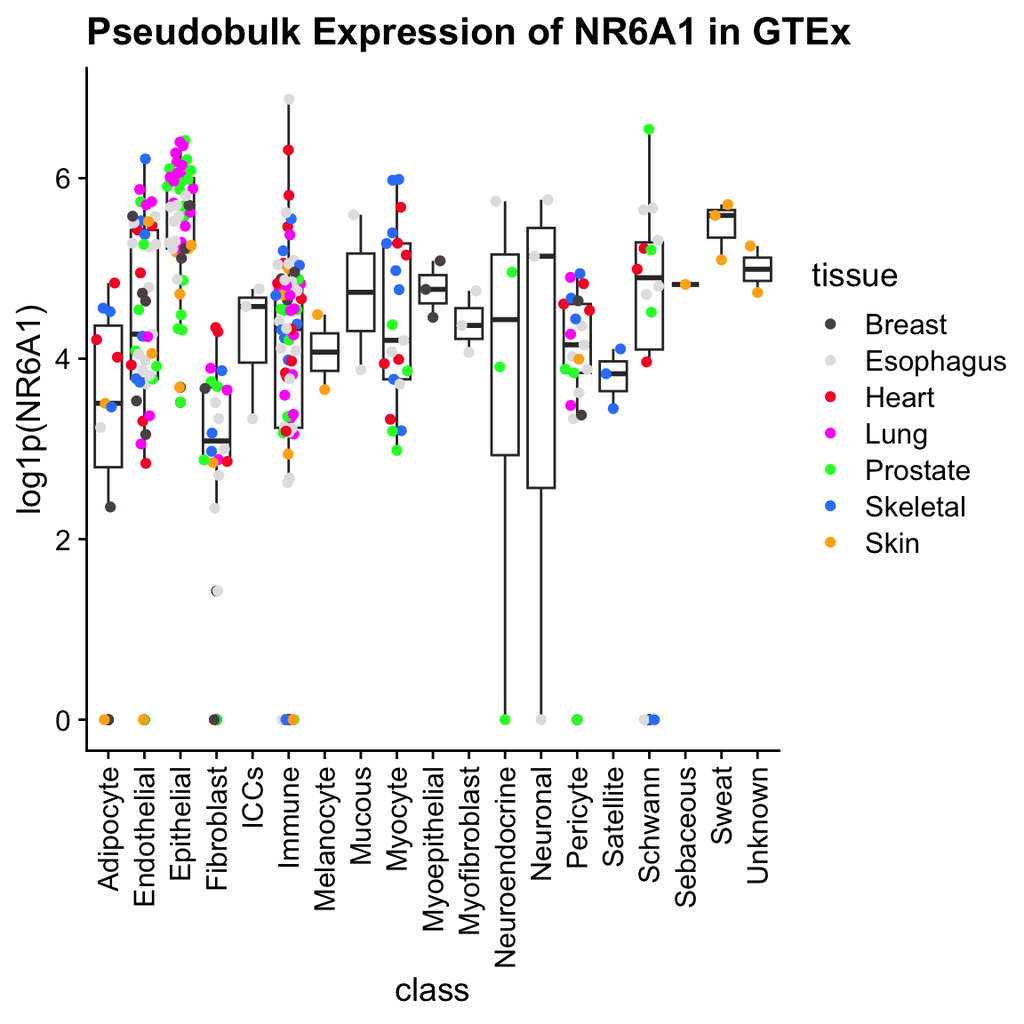

```r
pb_long_gtex %>%
  filter(name == 'NR6A1') %>%
  ggplot(aes(x=class,y=value)) +
  geom_boxplot() +
  ggbeeswarm::geom_quasirandom(aes(color=tissue)) +
  ylab("log1p(NR6A1)") +
  cowplot::theme_cowplot() +
  ggtitle("Pseudobulk Expression of NR6A1 in GTEx") +
  scale_color_manual(values = pals::polychrome() %>% unname()) +
  scale_x_discrete(guide = guide_axis(angle = 90))
```

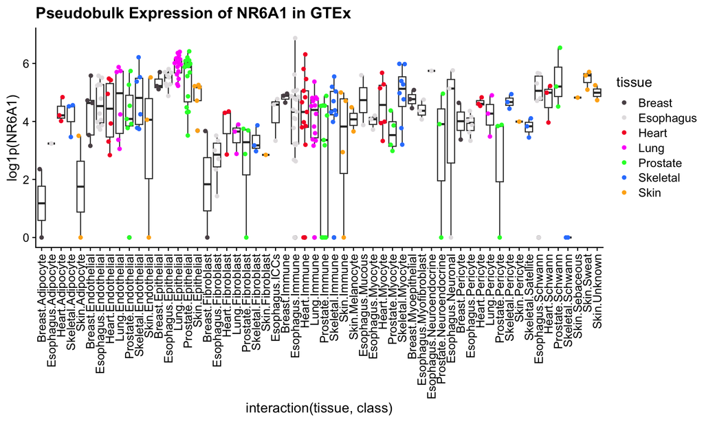

```r
pb_long_gtex %>%
  filter(name == 'NR6A1') %>%
  ggplot(aes(x=interaction(tissue,class),y=value)) +
  geom_boxplot() +
  ggbeeswarm::geom_quasirandom(aes(color=tissue)) +
  ylab("log1p(NR6A1)") +
  cowplot::theme_cowplot() +
  ggtitle("Pseudobulk Expression of NR6A1 in GTEx") +
  scale_color_manual(values = pals::polychrome() %>% unname()) +
  scale_x_discrete(guide = guide_axis(angle = 90))
```

# session

```r
save.image('../data/01_image.Rdata')
devtools::session_info()
```